# Assignment 6

## 8.5

For your retail data (from Exercise 3 in Section 2.10), find the appropriate order of differencing (after transformation if necessary) to obtain stationary data.

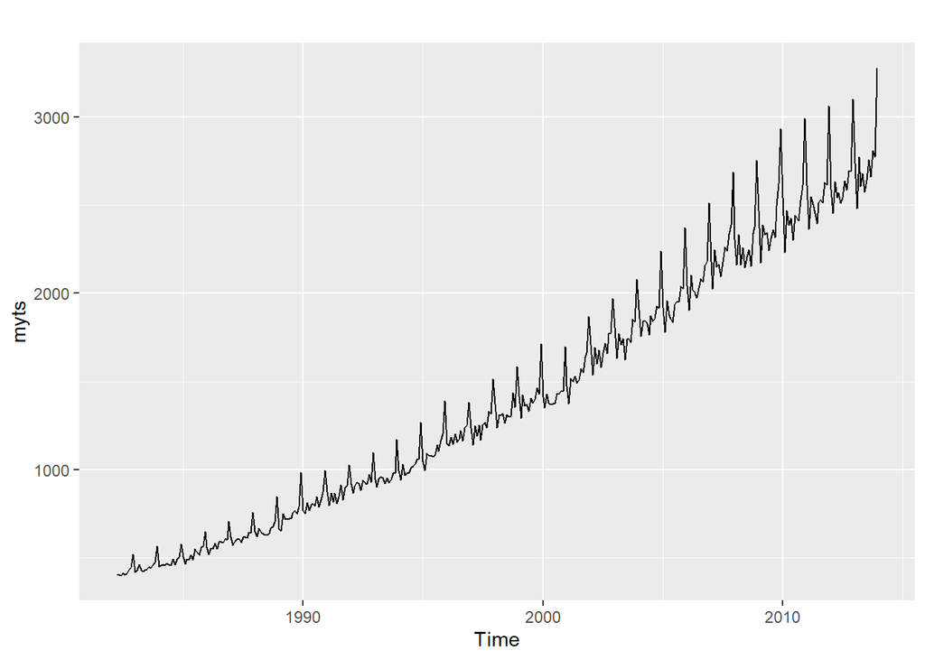

```r
retaildata <- read_excel('retail.xlsx', skip=1)
myts <- ts(retaildata[,"A3349398A"],frequency=12, start=c(1982,4))
autoplot(myts)
```

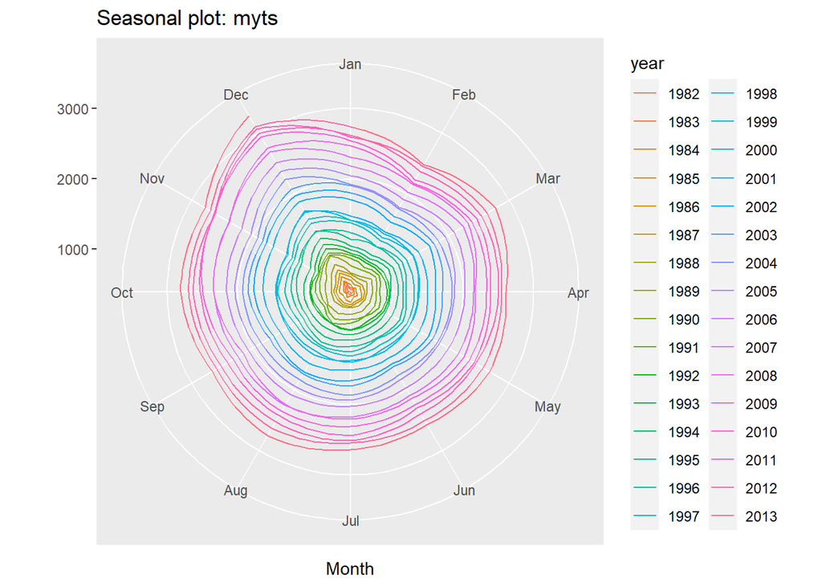

```r
ggseasonplot(myts, polar = TRUE)
```

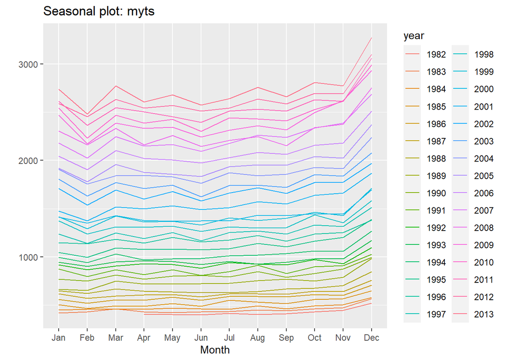

```r
ggseasonplot(myts)
```

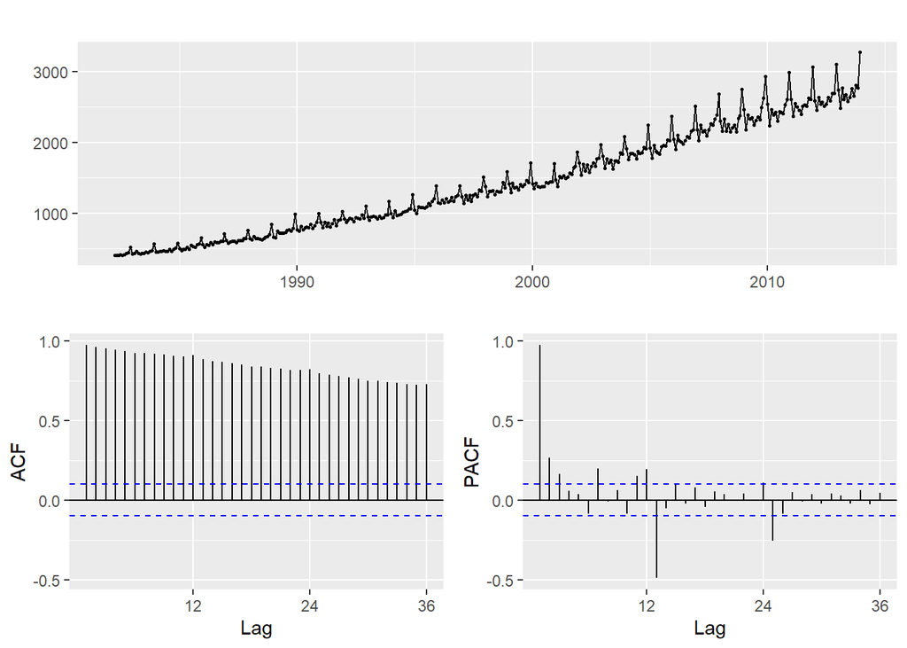

```r
ggtsdisplay(myts)
```

- Upwards trend multiplicative trend
- Strong seasonaly

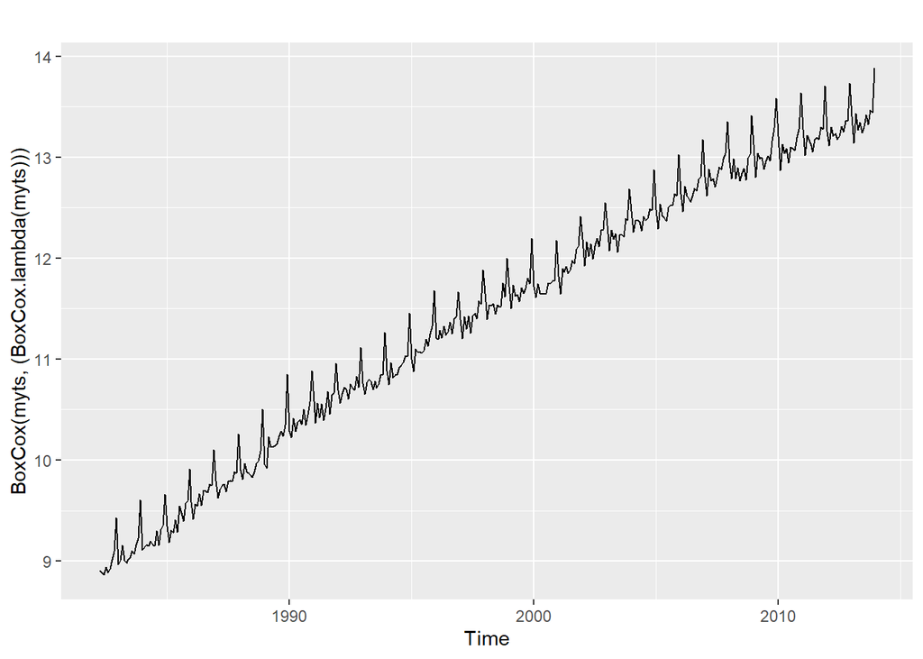

```r
autoplot(BoxCox(myts, (BoxCox.lambda(myts))))
```

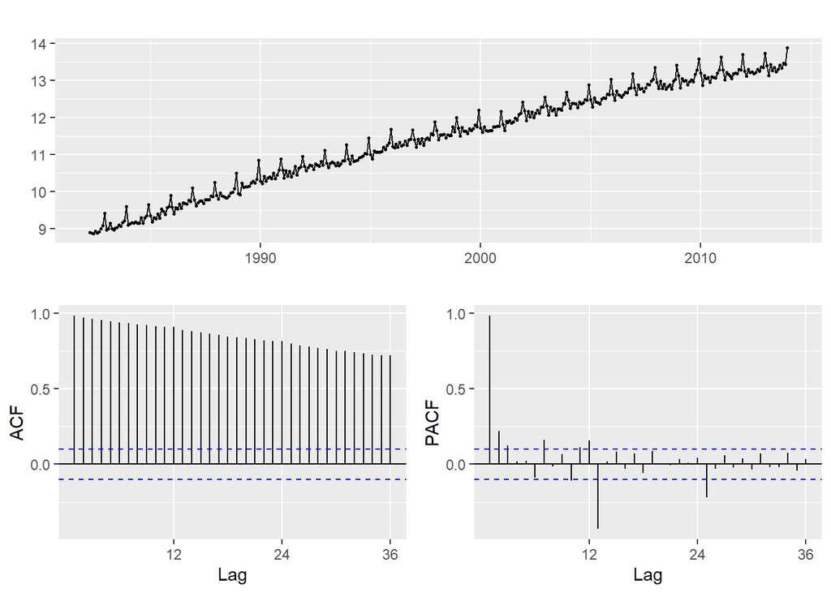

```r
ggtsdisplay(BoxCox(myts, BoxCox.lambda(myts)))
```

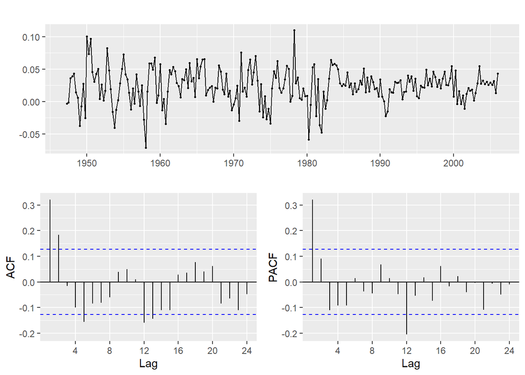

```r
ggtsdisplay(usgdp  %>% BoxCox(BoxCox.lambda(myts)) %>% diff(1))
```

```r
usgdp %>% BoxCox(BoxCox.lambda(myts)) %>% diff(1) %>% ur.kpss() %>% summary()
```

```
##
## #######################
## # KPSS Unit Root Test #
## #######################
##
## Test is of type: mu with 4 lags.
##
## Value of test-statistic is: 0.0278
##
## Critical value for a significance level of:
##                 10pct  5pct 2.5pct  1pct
## critical values 0.347 0.463  0.574 0.739
```

## 8.6

Use R to simulate and plot some data from simple ARIMA models. ### a. Use the following R code to generate data from an AR(1) model with $\phi _{1} = 0.6$ and $\sigma ^{2} = 1$ . The process starts with $y_{1} = 0$.

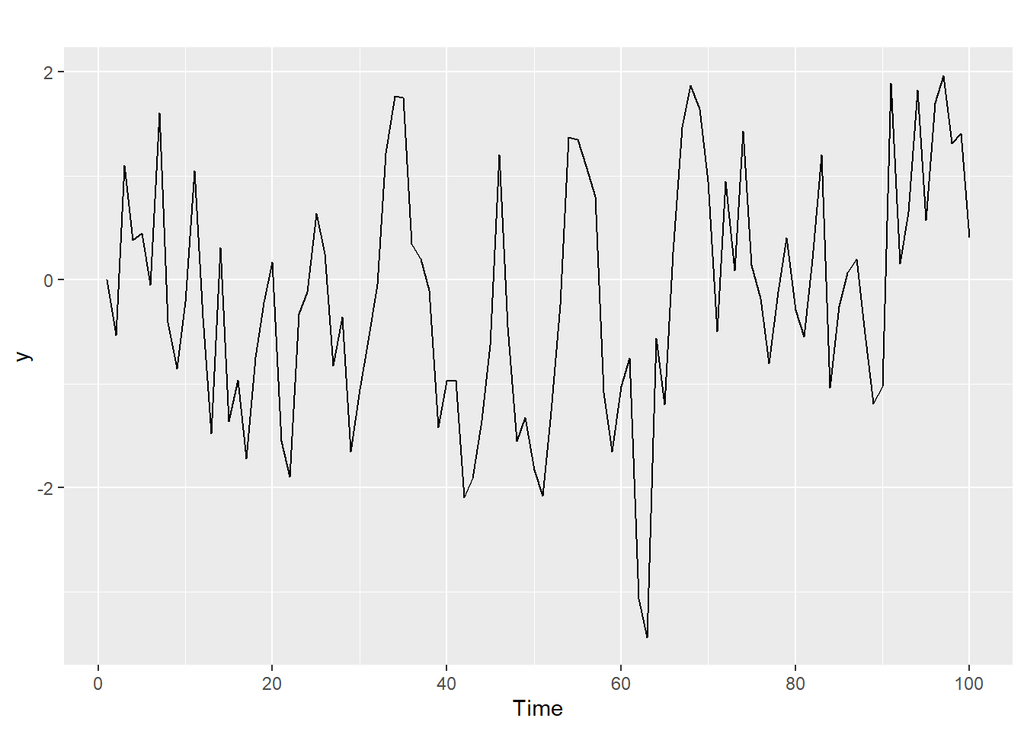

```r
y <- ts(numeric(100))
e <- rnorm(100)
for(i in 2:100)
   y[i] <- 0.6*y[i-1] + e[i]

autoplot(y)
```

### b.

Produce a time plot for the series. How does the plot change as you change $\phi _{1}$?

```r
ar <- function(theta){
  y <- ts(numeric(100))
  e <- rnorm(100)
  for(i in 2:100){
    y[i] <- 0.6*y[i-1] + e[i]}
  return(y)
}
```

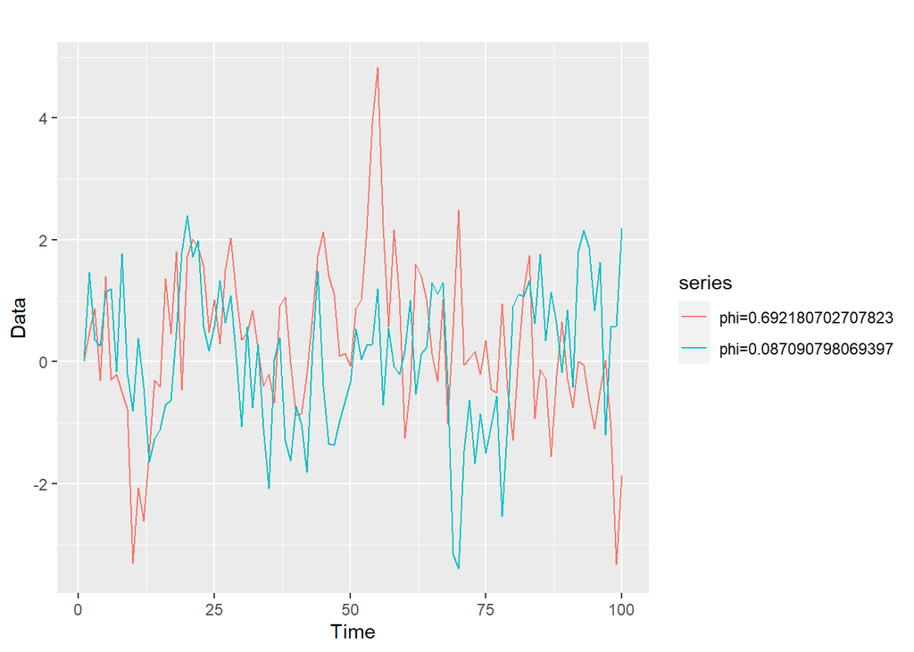

```r
set.seed(346)

data <- list()
i<- 0

phi_values <- runif(2, min = 0.0001, max = .9)

for (phi in phi_values)
  {
  i<- i+1
  data[[i]] <- ar(phi)
  }

data2 <- do.call(cbind,data)

colnames(data2) <- paste("phi=", phi_values, sep = '')

autoplot(data2) + ylab('Data')
```

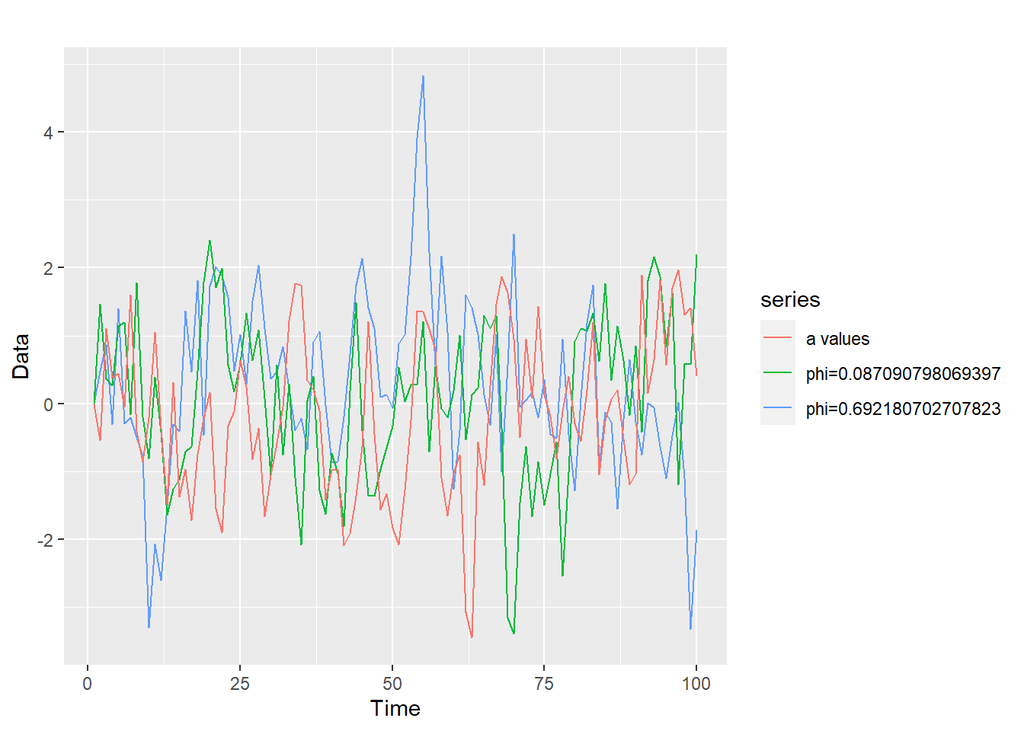

```r
autoplot(data2, series = "b values")+
  autolayer(y, series = "a values")+
  ylab('Data')
```

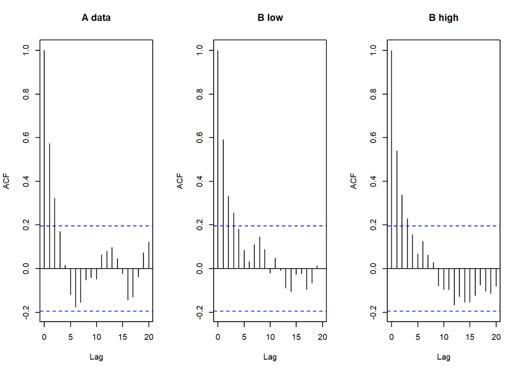

```r
b_data_low <- data2[,1]
b_data_high <- data2[,2]

par(mfrow=c(1,3))
acf(y, main="A data");
acf(b_data_low, main = "B low");
acf(b_data_high, main = "B high")
```

### c.

Write your own code to generate data from an MA(1) model with $\Theta _{1} = 0.6$ and $\sigma ^{2} = 1$.

```r
ma <- function(theta){
  y <- ts(numeric(100))
  e <- rnorm(100)
  for(i in 2:100){
    y[i] <- theta*e[i-1] + e[i]}
  return(y)
}
```

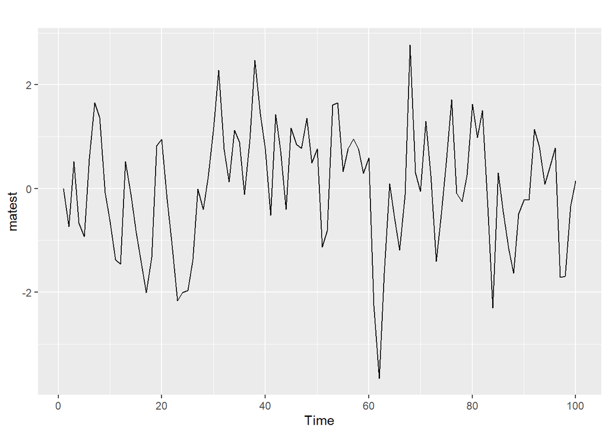

```r
matest <- ma(0.6)
autoplot(matest)
```

### d.

Produce a time plot for the series. How does the plot change as you change $\phi _{1}$?

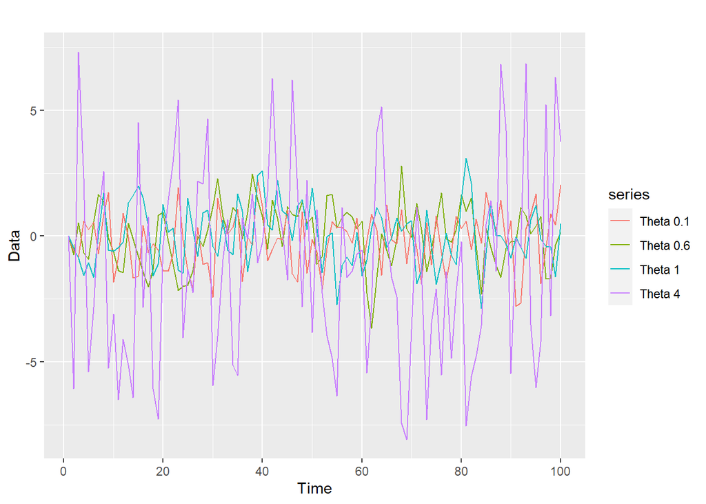

```r
ma_2 <- ma(.1)
ma_3 <- ma(1)
ma_4 <- ma(4)

autoplot(matest, series = "Theta 0.6")+
  autolayer(ma_2, series = "Theta 0.1")+
  autolayer(ma_3, series = "Theta 1")+
  autolayer(ma_4, series = "Theta 4")+
  ylab('Data')
```

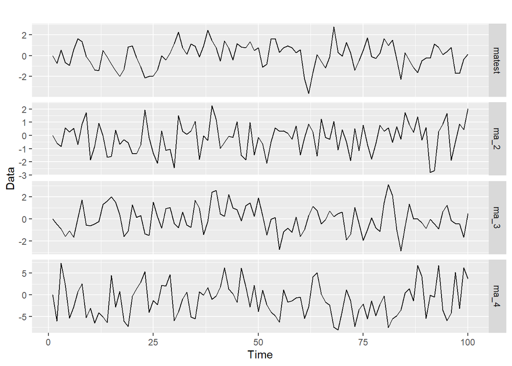

```r
autoplot(cbind(matest, ma_2, ma_3, ma_4), facet = TRUE)+
  ylab('Data')
```

### e.

Generate data from an ARMA(1,1) model with $\phi _{1} = 0.6$, $\Theta _{1} = 0.6$ and $\sigma ^{2} = 1$.

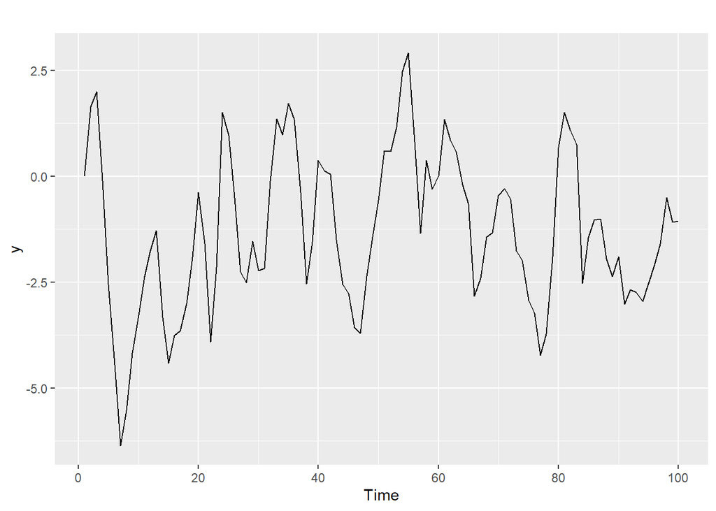

```r
y <- ts(numeric(100))
e <- rnorm(100)

for(i in 2:100){
    y[i] <- 0.6*y[i-1] + 0.6*e[i-1] + e[i]}

autoplot(y)
```

### f.

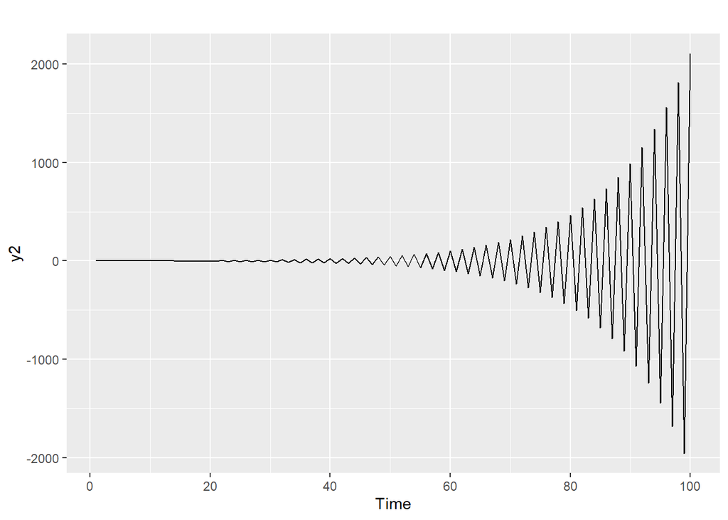

```r
y2 <- ts(numeric(100))
e <- rnorm(100)

for(i in 3:100){
  y2[i] <- (-0.8)*y2[i-1] + 0.3*y2[i-2] + e[i]
}
autoplot(y2)
```

### g.

Graph the latter two series and compare them.

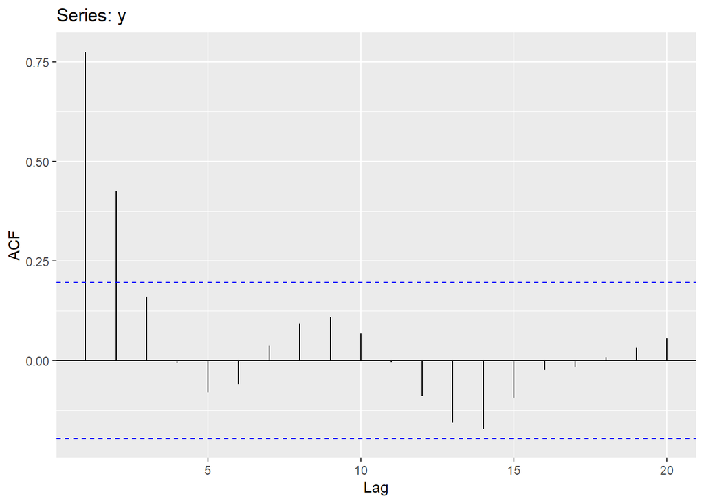

```r
ggAcf(y)
```

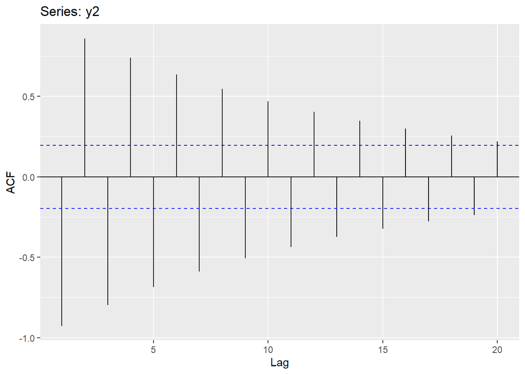

```r
ggAcf(y2)
```